# HW3-Markdown

Tra Reynolds, Sumin Kang, Ryan Martin

2025-11-11

Sumin Kang:https://chatgpt.com/share/69136d89-a134-8010-80c4-8255e2c9899a

# 1 Refactored HW2 into Functions

## 1.1 label_by_median()

```r
#' @param x A numeric vector (can contain NA values).
#'
#' @return A data.frame with:
#'   - value: the original values
#'   - label: "below" or "at or above" (NA if value is NA)
#'
#' @examples
#' label_by_median(c(1, 5, 2, NA))
label_by_median <- function(x) {
  # Input checks
  if (!is.numeric(x)) {
    stop("`x` must be a numeric vector.")
  }

  # Compute median ignoring NAs
  med <- stats::median(x, na.rm = TRUE)

  # Create labels; NAs stay NA
  label <- ifelse(is.na(x),
                  NA_character_,
                  ifelse(x >= med, "at or above", "below"))

  # Return table
  data.frame(
    value = x,
    label = label,
    stringsAsFactors = FALSE
  )
}
```

```r
# Example runs of 1.1
#' The following code sections will run without errors and demonstrates
#' that 1.1 works for numeric vectors.
x_demo <- c(1, 5, 2, 8, NA, 4)
x_demo
```

```
## [1]  1  5  2  8 NA  4
```

```r
xdemo_label <- label_by_median(x_demo)
xdemo_label
```

```
##   value       label
## 1     1       below
## 2     5 at or above
## 3     2       below
## 4     8 at or above
## 5    NA        <NA>
## 6     4 at or above
```

```r
#' The following code sections will not fully run and demonstrates
#' that 1.1 does not work for non-numeric vectors.

ydemo <- c("a", "b", "c", "d", NA, 4)
ydemo
```

```
## [1] "a" "b" "c" "d" NA  "4"
```

```r
ydemo_label <- label_by_median(ydemo)
```

```
## Error in label_by_median(ydemo): `x` must be a numeric vector.
```

## 1.2 even_until()

```r
#' Collect even numbers up to n, stopping at first multiple of k
#'
#' @param n Positive integer. Upper limit of the loop.
#' @param k Positive integer. Stop as soon as the current i is a multiple of k.
#'
#' @return An integer vector of even numbers encountered before
#'   hitting the first multiple of k (the multiple itself is not included).
#'
#' @examples
#' even_until(20, 6)
even_until <- function(n, k) {
  # Input checks
  if (!is.numeric(n) || length(n) != 1 || !is.finite(n) || n <= 0 || n %% 1 != 0) {
    stop("`n` must be a single positive integer.")
  }
  if (!is.numeric(k) || length(k) != 1 || !is.finite(k) || k <= 0 || k %% 1 != 0) {
    stop("`k` must be a single positive integer.")
  }

  n <- as.integer(n)
  k <- as.integer(k)

  evens <- integer(0L)

  for (i in seq_len(n)) {
    # Skip odds
    if (i %% 2L == 1L) {
      next
    }

    # Stop at first multiple of k (do NOT include it)
    if (i %% k == 0L) {
      break
    }

    evens <- c(evens, i)
  }

  evens
}
```

```r
# Example runs of 1.2

even_until(20, 5)   # stops at 10
```

```
## [1] 2 4 6 8
```

```r
even_until(40, 17)  # stops at 34
```

```
##  [1]  2  4  6  8 10 12 14 16 18 20 22 24 26 28 30 32
```

```r
# Edge-ish cases:
even_until(30, 17)  # no multiple of k within 1:n
```

```
##  [1]  2  4  6  8 10 12 14 16 18 20 22 24 26 28 30
```

```r
even_until(10, 2)   # stops immediately at first multiple of 2
```

```
## integer(0)
```

## 1.3 sum_until()

```r
#' Draw random numbers and sum until threshold is exceeded
#'
#' @param thresh Positive numeric scalar. Stop when running total exceeds this.
#' @param rng A function to generate random numbers. Must accept
#'   at least a first argument n (number of draws). Default is runif.
#' @param ... Additional arguments passed to `rng`.
#'
#' @return A list with:
#'   - total: final sum (first value > thresh)
#'   - draws: numeric vector of all draws used
#'
#' @examples
#' set.seed(1)
#' sum_until()                    # default: runif(., 0, 1), thresh = 1
#' set.seed(1)
#' sum_until(thresh = 5, rng = rexp, rate = 2)
sum_until <- function(thresh = 1, rng = stats::runif, ...) {
  # Input checks
  if (!is.numeric(thresh) || length(thresh) != 1 || !is.finite(thresh) || thresh <= 0) {
    stop("`thresh` must be a single positive, finite numeric value.")
  }
  if (!is.function(rng)) {
    stop("`rng` must be a function that accepts at least a first argument `n`.")
  }

  total <- 0
  draws <- numeric(0)

  while (total <= thresh) {
    x <- rng(1, ...)  # draw one number

    if (!is.numeric(x) || length(x) != 1 || is.na(x) || !is.finite(x)) {
      stop("`rng` must return a single finite numeric value for n = 1.")
    }

    draws <- c(draws, x)
    total <- total + x
  }

  list(
    total = total,
    draws = draws
  )
}
```

```r
# Example runs of 1.3

set.seed(123)

# Default (runif on (0,1), thresh = 1)
res_sum_default <- sum_until()
res_sum_default
```

```
## $total
## [1] 1.075883
##
## $draws
## [1] 0.2875775 0.7883051
```

```r
# Custom RNG: Exponential( rate = 2 ), threshold 5
set.seed(123)
res_sum_exp <- sum_until(thresh = 5, rng = rexp, rate = 2)
res_sum_exp
```

```
## $total
## [1] 5.556373
##
## $draws
##  [1] 0.42172863 0.28830514 0.66452743 0.01578868 0.02810549 0.15825061
##  [7] 0.15711365 0.07263340 1.36311823 0.01457672 0.50241503 0.24010736
## [13] 0.14050681 0.18855892 0.09414202 0.42489306 0.78160177
```

## 1.4 estimate_pi()

```r
#' Estimate pi via Monte Carlo darts in the unit square
#'
#' @param n Positive integer. Number of darts to throw.
#'
#' @return A list with:
#'   - inside: number of darts landing inside the unit quarter circle
#'   - n: total number of darts
#'   - pi_hat: Monte Carlo estimate of pi (4 * inside / n)
#'
#' @examples
#' set.seed(1)
#' estimate_pi(10^4)
estimate_pi <- function(n) {
  # Input checks
  if (!is.numeric(n) || length(n) != 1 || !is.finite(n) || n <= 0 || n %% 1 != 0) {
    stop("`n` must be a single positive integer.")
  }

  n <- as.integer(n)
  inside <- 0L

  for (i in seq_len(n)) {
    x <- stats::runif(1)
    y <- stats::runif(1)
    if (x^2 + y^2 <= 1) {
      inside <- inside + 1L
    }
  }

  pi_hat <- 4 * inside / n

  list(
    inside = inside,
    n      = n,
    pi_hat = pi_hat
  )
}
```

```r
# Example runs of 1.4

set.seed(123)

# More darts increase accuracy
res_pi_1e4 <- estimate_pi(10000)
res_pi_1e4
```

```
## $inside
## [1] 7950
##
## $n
## [1] 10000
##
## $pi_hat
## [1] 3.18
```

```r
res_pi_1e5 <- estimate_pi(100000)
res_pi_1e5
```

```
## $inside
## [1] 78607
##
## $n
## [1] 100000
##
## $pi_hat
## [1] 3.14428
```

## 1.5 rw_sim()

```r
#' Simulate a simple symmetric random walk with early stopping
#'
#' @param n_steps Positive integer. Maximum number of steps to simulate.
#' @param boundary Positive numeric. Stop when |S_t| > boundary.
#'
#' @return A list with:
#'   - S: numeric vector of positions S_0, S_1, ..., S_T (T <= n_steps)
#'   - stop_time: the time t at which |S_t| > boundary, or NA if never exceeded
#'
#' @examples
#' set.seed(1)
#' rw_sim(n_steps = 100, boundary = 10)
rw_sim <- function(n_steps = 1000L, boundary = 10) {
  # Input checks
  if (!is.numeric(n_steps) || length(n_steps) != 1 || !is.finite(n_steps) ||
      n_steps <= 0 || n_steps %% 1 != 0) {
    stop("`n_steps` must be a single positive integer.")
  }
  if (!is.numeric(boundary) || length(boundary) != 1 || !is.finite(boundary) ||
      boundary <= 0) {
    stop("`boundary` must be a single positive, finite numeric value.")
  }

  n_steps <- as.integer(n_steps)

  # S_0 = 0, allocate max length n_steps + 1
  S <- numeric(n_steps + 1L)
  S[1] <- 0
  stop_time <- NA_integer_

  for (t in 2:(n_steps + 1L)) {
    step <- sample(c(-1L, 1L), size = 1L)
    S[t] <- S[t - 1L] + step

    if (abs(S[t]) > boundary) {
      stop_time <- t - 1L  # time index in terms of steps (S_t)
      S <- S[1:t]          # truncate to actual path length
      break
    }
  }

  list(
    S = S,
    stop_time = stop_time
  )
}
```

```r
# Example runs of 1.5

set.seed(123)

rw_res <- rw_sim(n_steps = 1000, boundary = 10)
rw_res$stop_time      # when (if) it crossed the boundary
```

```
## [1] 53
```

```r
head(rw_res$S)        # first few positions
```

```
## [1]  0 -1 -2 -3 -2 -3
```

```r
length(rw_res$S)      # length of the path
```

```
## [1] 54
```

# 2 Alternative Functions

## 2.1 Thresholded Labeling with Custom Statistic

```r
label_by_stat <- function(x, stat = function(v) stats::median(v, na.rm = TRUE)) {
  # basic checks
  if (!is.numeric(x)) stop("`x` must be a numeric vector.")
  if (!is.function(stat)) stop("`stat` must be a function.")

  # compute threshold
  thr <- stat(x)
  if (!is.numeric(thr) || length(thr) != 1L || !is.finite(thr)) {
    stop("`stat(x)` must return a single finite numeric value.")
  }

  # label values; keep NA as NA
  lab <- ifelse(is.na(x), NA_character_,
                ifelse(x >= thr, "at or above", "below"))

  data.frame(
    value = x,
    label = lab,
    threshold = rep(thr, length(x)),
    row.names = NULL,
    stringsAsFactors = FALSE
  )
}

# ---Results------------------------------------------------------------

set.seed(42)
z <- c(rnorm(12), NA)

# default (median)
head(label_by_stat(z))
```

```
##        value       label threshold
## 1  1.3709584 at or above 0.5185655
## 2 -0.5646982       below 0.5185655
## 3  0.3631284       below 0.5185655
## 4  0.6328626 at or above 0.5185655
## 5  0.4042683       below 0.5185655
## 6 -0.1061245       below 0.5185655
```

```r
# mean threshold
head(label_by_stat(z, stat = function(v) mean(v, na.rm = TRUE)))
```

```
##        value       label threshold
## 1  1.3709584 at or above 0.7553736
## 2 -0.5646982       below 0.7553736
## 3  0.3631284       below 0.7553736
## 4  0.6328626       below 0.7553736
## 5  0.4042683       below 0.7553736
## 6 -0.1061245       below 0.7553736
```

```r
# 75th percentile threshold
head(label_by_stat(z, stat = function(v) stats::quantile(v, 0.75, na.rm = TRUE)))
```

```
##        value label threshold
## 1  1.3709584 below  1.406099
## 2 -0.5646982 below  1.406099
## 3  0.3631284 below  1.406099
## 4  0.6328626 below  1.406099
## 5  0.4042683 below  1.406099
## 6 -0.1061245 below  1.406099
```

By parameterizing the threshold via `stat`, the same labeling logic flexibly adapts to different summaries of the data as the chosen statistic increases from the median -> mean -> 75th percentile, the cutoff becomes more stringent and fewer observations are labeled “at or above”, while `NA` values are carried through unchanged.

## 2.2 Generalized Accumulator with Stop Rule

```r
accumulate_until <- function(step_fun, stop_rule, max_iters = 1e6) {
  if (!is.function(step_fun)) stop("`step_fun` must be a zero-arg function.")
  if (!is.function(stop_rule)) stop("`stop_rule` must be a one-arg function.")
  if (!is.numeric(max_iters) || length(max_iters) != 1 || max_iters <= 0) {
    stop("`max_iters` must be a positive scalar.")
  }

  total <- 0
  trace <- numeric(0)
  iters <- 0L

  repeat {
    inc <- step_fun()
    if (!is.numeric(inc) || length(inc) != 1L || !is.finite(inc)) {
      stop("`step_fun()` must return a single finite numeric value.")
    }

    total <- total + inc
    iters <- iters + 1L
    trace <- c(trace, total)

    if (isTRUE(stop_rule(total))) break
    if (iters >= max_iters) stop("Reached `max_iters` without satisfying `stop_rule`.")
  }

  list(total = total, iters = iters, trace = trace)
}

# --- sum Uniform(0,1) until total > -----------------------------------
set.seed(123)
acc_demo <- accumulate_until(
  step_fun  = function() stats::runif(1),  # U(0,1)
  stop_rule = function(total) total > 6    # stop when total exceeds 6
)
acc_demo$total
```

```
## [1] 6.739308
```

```r
acc_demo$iters
```

```
## [1] 11
```

```r
head(acc_demo$trace)
```

```
## [1] 0.2875775 1.0758827 1.4848596 2.3678770 3.3083443 3.3539008
```

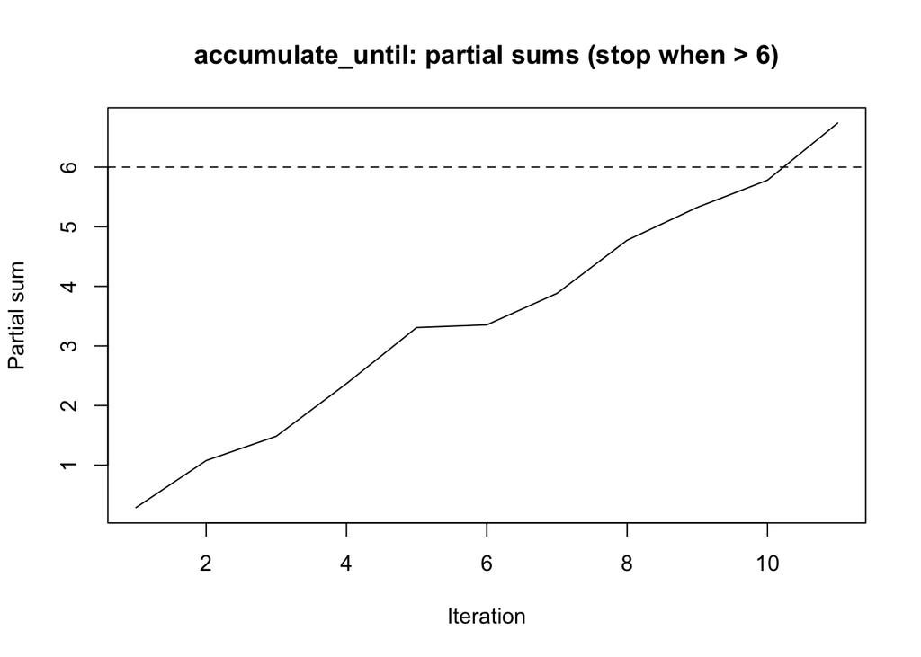

```r
# optional: quick plot of partial sums
plot(acc_demo$trace, type = "l", xlab = "Iteration", ylab = "Partial sum",
     main = "accumulate_until: partial sums (stop when > 6)")
abline(h = 6, lty = 2)
```

* The accumulator stops at **interation 11** with total ≈ 6.7393 (>6), matching the console output and plot.  
* `trace` records the partial sums after each increment, it is monotonically increasing and crosses the dashed 6-line between iterations 10 and 11.  
* Design notes: `step_fun()` must return a single finite numeric increment, accumulation stops immediately when `stop_rule(total)` becomes `TRUE`, and the function returns a list containing `total`, `iter`, and `trace`.  
* Intuition: since each increment follows U(0,1) with an expected value of 0.5, the total is expected to exceed 6 after roughly 6/0.5 ≈ 12 iterations. The observed result of 11 iterations is therefore reasonable and within expectation.

## 2.3 Random Walk with Reflecting Boundaries

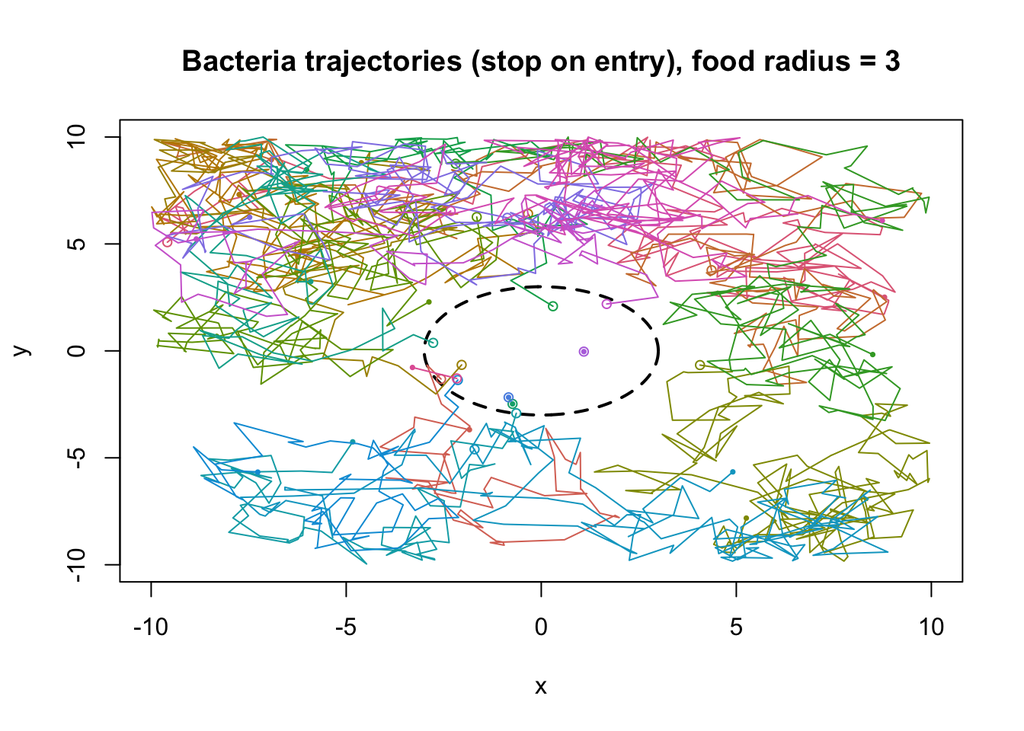

```r
simulate_bacteria <- function(N = 20, T = 150, a = 0, b = 2,
                              move = FALSE, box_half_size = 10, food_r = 3) {
  # input checks
  if (!is.numeric(N) || N <= 0 || N %% 1 != 0) stop("`N` must be a positive integer.")
  if (!is.numeric(T) || T <= 0 || T %% 1 != 0) stop("`T` must be a positive integer.")
  if (!is.numeric(a) || !is.numeric(b) || a < 0 || b <= a) stop("Require 0 <= a < b.")
  if (!is.numeric(box_half_size) || box_half_size <= 0) stop("`box_half_size` > 0.")
  if (!is.numeric(food_r) || food_r <= 0) stop("`food_r` > 0.")
  box <- box_half_size

  # helpers
  in_food <- function(x, y) (x^2 + y^2) <= food_r^2

  # reflect a scalar position into [-bound, bound] (handles multiple crossings)
  reflect_1d <- function(pos, bound) {
    p <- pos
    while (p < -bound || p > bound) {
      if (p >  bound) p <-  2*bound - p
      if (p < -bound) p <- -2*bound - p
    }
    p
  }

  # initial positions ~ U(-9, 9)
  x <- stats::runif(N, -9, 9)
  y <- stats::runif(N, -9, 9)

  frozen <- rep(FALSE, N)   # TRUE once it freezes (move=FALSE and inside)
  inside <- in_food(x, y)

  # preallocate trajectory storage
  out_id <- integer((T + 1L) * N)
  out_t  <- integer((T + 1L) * N)
  out_x  <- numeric((T + 1L) * N)
  out_y  <- numeric((T + 1L) * N)
  out_in <- logical((T + 1L) * N)

  write_row <- 0L
  write_step <- function(tt, xx, yy, ins) {
    idx <- (write_row + 1L):(write_row + N)
    out_id[idx] <<- seq_len(N)
    out_t[idx]  <<- tt
    out_x[idx]  <<- xx
    out_y[idx]  <<- yy
    out_in[idx] <<- ins
    write_row    <<- write_row + N
  }

  # record t = 0
  write_step(0L, x, y, inside)

  # simulate
  for (t in 1:T) {
    for (i in 1:N) {
      if (frozen[i]) next

      # propose a step
      s     <- stats::runif(1, a, b)
      theta <- stats::runif(1, 0, 2*pi)
      x_new <- x[i] + s * cos(theta)
      y_new <- y[i] + s * sin(theta)

      # reflect off the square boundary
      x_new <- reflect_1d(x_new, box)
      y_new <- reflect_1d(y_new, box)

      if (!inside[i]) {
        # currently outside
        if (in_food(x_new, y_new)) {
          inside[i] <- TRUE
          if (!isTRUE(move)) {
            # freeze at first entry
            x[i] <- x_new; y[i] <- y_new
            frozen[i] <- TRUE
            next
          } else {
            # keep moving (now inside)
            x[i] <- x_new; y[i] <- y_new
            next
          }
        } else {
          # still outside
          x[i] <- x_new; y[i] <- y_new
          next
        }
      } else {
        # already inside
        if (!isTRUE(move)) {
          # should be frozen; guard
          frozen[i] <- TRUE
          next
        } else {
          # keep moving but must remain inside: resample until inside
          tries <- 0L
          repeat {
            if (in_food(x_new, y_new)) break
            tries <- tries + 1L
            if (tries > 500L) break  # safety
            s     <- stats::runif(1, a, b)
            theta <- stats::runif(1, 0, 2*pi)
            x_new <- x[i] + s * cos(theta)
            y_new <- y[i] + s * sin(theta)
            x_new <- reflect_1d(x_new, box)
            y_new <- reflect_1d(y_new, box)
          }
          x[i] <- x_new; y[i] <- y_new
        }
      }
    }
    write_step(t, x, y, inside)
  }

  traj <- data.frame(
    id     = out_id,
    t      = out_t,
    x      = out_x,
    y      = out_y,
    inside = out_in,
    row.names = NULL
  )
  final <- traj[traj$t == T, c("id","x","y","inside")]
  rownames(final) <- NULL

  list(
    traj  = traj,
    final = final,
    meta  = list(N = N, T = T, a = a, b = b, move = move,
                 box_half_size = box_half_size, food_r = food_r)
  )
}

# --- plots ------------------------------------------------------------

set.seed(7)
sim_stop <- simulate_bacteria(N = 20, T = 150, a = 0, b = 2, move = FALSE)

# plot trajectories with different colors; overlay the food circle (radius 3)
ids  <- sort(unique(sim_stop$traj$id))
cols <- grDevices::hcl.colors(length(ids), palette = "Dark3")
plot(NA, xlim = c(-10, 10), ylim = c(-10, 10), xlab = "x", ylab = "y",
     main = "Bacteria trajectories (stop on entry), food radius = 3")
th <- seq(0, 2*pi, length.out = 500)
lines(3*cos(th), 3*sin(th), lwd = 2, lty = 2)
for (j in seq_along(ids)) {
  d <- sim_stop$traj[sim_stop$traj$id == ids[j], ]
  lines(d$x, d$y, col = cols[j])
  points(d$x[1], d$y[1], pch = 16, cex = 0.5, col = cols[j])              # start
  points(d$x[nrow(d)], d$y[nrow(d)], pch = 1,  cex = 0.8, col = cols[j])  # end
}
```

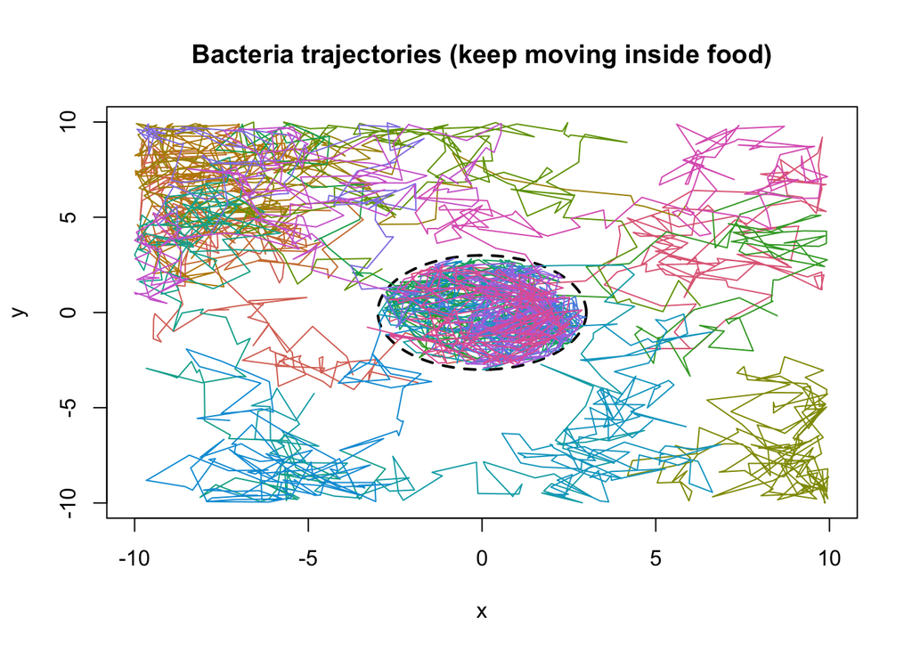

```r
# move = TRUE: keep moving within the circle
set.seed(7)
sim_move <- simulate_bacteria(N = 20, T = 150, a = 0, b = 2, move = TRUE)
plot(NA, xlim = c(-10, 10), ylim = c(-10, 10), xlab = "x", ylab = "y",
     main = "Bacteria trajectories (keep moving inside food)")
lines(3*cos(th), 3*sin(th), lwd = 2, lty = 2)
for (j in seq_along(ids)) {
  d <- sim_move$traj[sim_move$traj$id == ids[j], ]
  lines(d$x, d$y, col = cols[j])
}
```

* **Model/logic**: Each bacterium starts at (x_0, y_0) ~ U(−9,9)^2 and takes “run-and-tumble” steps (x_t+1, y_t+1) = (x_t, y_t) + St(cosδt, sinδt) with St ~ U(0,2), δt ∼ U(0,2π).  
Reflecting boundaries keep positions inside the square [-10, 10]^2; a helper checks whether a point is inside the food circle of radius 3.  
* **Return values**: `simulate_bacteria()` returns the full trajectory table (id, time, x, y, inside) and the final locations at t = T.  
Two hehaviors are controlled by `move`:  
- `move - FALSE` (stop on entry): a bacterium freezes the first time it enters the food circle.  
- `move = TRUE` (keep moving inside): after first entry, all subsequent steps are constrained to remain in the circle.  
* **Stop on entry**: Paths looks like standard random walks with occasional wall bounces. Many trajectories terminate on the dashed circle, producing end markers clustered just inside radius 3. Outside the food region, movement continues until first hit; once hit, the path ends (flat thereafter).  
* **Keep moving inside**: Outside the circle, trajectories look the same as above; after entry, motion continues but is confined within the circle, producing a dense “spaghetti cloud” inside the dashed boundary. This visually confirms the rule is enforced.  
* **Sanity checks visible in the plot**  
- All coordinates remain within [-10, 10] -> reflections work.  
- The food boundary is a circle of radius 3 centered at the origin.  
- With `move = FALSE`, endpoints concentrate near the circle; with move = TRUE, time spent inside is high after entry, so the interior fills in.

# 3 Rashomon-Lite Package

## 3.1 Core Functions

## 3.2 Minimal Package